# Preliminary pier seine work

Mike O’Brien

26 March, 2021

## Start up

### Load packages

```r
library(ggplot2); library(mgcv); library(gratia); library(data.table)
```

### Load length data

```r
lengths <- fread('data/derived/lengths.csv')
lengths[, yr_fac := as.factor(year)]
lengths[, record_num := as.factor(record_num)]

head(lengths)
```

| record_num | scientific | length | cpue | date | day | month | year | gear | participants | temp | sal | time start | weather/notes | float_num | dl_feet | dl_meters | full_length | wk | yr_fac |
| --- | --- | --- | --- | --- | --- | --- | --- | --- | --- | --- | --- | --- | --- | --- | --- | --- | --- | --- | --- |
| 19 | pomatomus saltatrix | 78 | TRUE | 1999-06-09 | 9 | June | 1999 | 4' seine wo/bag | AM; BP; EH | 23.2 | 14.0 | NA | clear, sunny | 66 | 100 | 30.48 | TRUE | 23 | 1999 |
| 38 | pomatomus saltatrix | 98 | TRUE | 1999-06-22 | 22 | June | 1999 | 4' seine wo/bag | AM; BP | 25.0 | 14.0 | NA | many sm ss. in water; 1st of 4 | 66 | 100 | 30.48 | TRUE | 25 | 1999 |
| 81 | pomatomus saltatrix | 81 | FALSE | 1999-06-22 | 22 | June | 1999 | 4' seine wo/bag | AM; BP | 25.0 | 14.0 | NA | 2nd of 4 tows | NA | NA | NA | TRUE | 25 | 1999 |
| 82 | pomatomus saltatrix | 95 | FALSE | 1999-06-22 | 22 | June | 1999 | 4' seine wo/bag | AM; BP | 25.0 | 14.0 | NA | 3rd of 4 tows | NA | NA | NA | TRUE | 25 | 1999 |
| 83 | pomatomus saltatrix | 104 | FALSE | 1999-06-22 | 22 | June | 1999 | 4' seine wo/bag | AM; BP | 25.0 | 14.0 | NA | 4th of 4 tows | NA | NA | NA | TRUE | 25 | 1999 |
| 39 | pomatomus saltatrix | 107 | FALSE | 1999-06-24 | 24 | June | 1999 | 4' seine wo/bag | BP; EH | 25.3 | 13.7 | NA | windy; sunny | NA | NA | NA | TRUE | 26 | 1999 |

## Summary of length data

These are the different species available (note that there are a few typos that I haven’t addressed at this time):

```
##  [1] "pomatomus saltatrix"               "atherinidae sp."
##  [3] ""                                  "brevoortia tyrannus"
##  [5] "leiostomus xanthurus"              "menidia menidia"
##  [7] "anchoa mitchilli"                  "morone saxatilis"
##  [9] "hypsoblennius hentz"               "strongylura marina"
## [11] "pomatomus saltatrix adult"         "anchoa hepsetus"
## [13] "paralichthys dentatus"             "callinectes sapidus"
## [15] "fundulus majalis"                  "micropogonias undulatus"
## [17] "menidia beryllina"                 "gobiesox strumosus"
## [19] "rhinoptera bonasus"                "anguilla rostrata"
## [21] "fundulus heteroclitus"             "symphurus plagiusa"
## [23] "synodus foetens"                   "sphoeroides maculatus"
## [25] "hyporhamphus unifasciatus"         "alosa pseudoharengus"
## [27] "alosa aestivalis"                  "membras beryllilna"
## [29] "morone americana"                  "fundulus diaphanus"
```

[output cut: 27 more lines]

We can also look at this visually. Note that there are plenty of misspellings that I’ll sort through later, but the main takeaway is that these species are the top-10 most-consistently sampled:

1. Atlantic silverside, *Menidia menidia*
2. Atlantic needlefish, *Strongylura marina*
3. blue crab, *Callinectes sapidus*
4. spot, *Leiostomus xanthurus*
5. inland silverside, *Menidia beryllina*
6. striped bass, *Morone saxatilis*
7. bluefish, *Pomatomaus saltatrix*
8. bay anchovy, *Anchoa mitchilli*
9. menhaden, *Brevoortia tyrannus*
10. gizzard shad
11. white perch, *Morone americana*
    - (going to 11 because we love white perch)

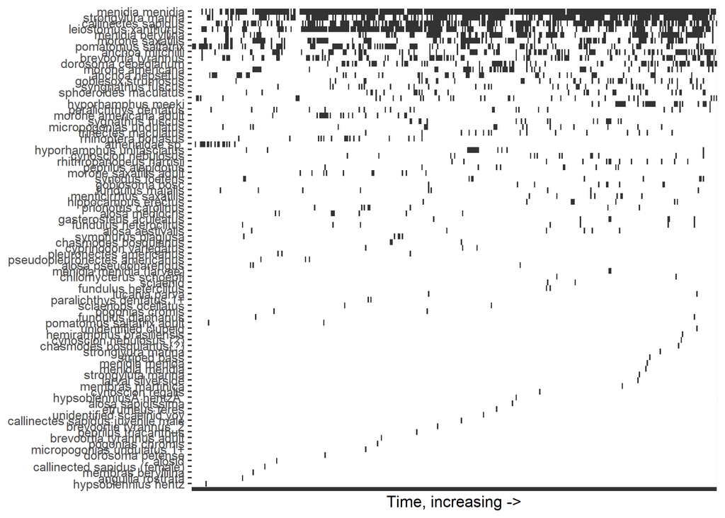

## Dirty models

For the first crack, I’m going to use a location, scale, and shape GAMM. This just means that I’m **not** going to assume that the standard deviation is constant at all points, but a function of some other terms. Since the fish are growing and other cohorts are recruiting throughout the summer, I’m going to first say that the variance in length is a smoothed function of week. Length itself will be a function of week, temperature, salinity, and a random intercept of year.

$length = \beta_0 + f(week) + f(temperature) + f(salinity) + \beta_{year}$

$length_{sd} = \beta_{sd} + f(week)$

**All of this is just a first guess, and is totally up for adjustment!!**

### Atlantic silverside

```r
atl <- lengths[grepl(' men', scientific)]

atl_mod <- gam(list(length ~
                      s(wk, k = 15, bs = 'cr') +
                      s(temp, bs = 'cr')+
                      s(sal, bs = 'cr') +
                      s(yr_fac, bs = 're'),
                    ~ s(wk, k = 15, bs = 'cr')),
               family = 'gaulss',
               data = atl,
               method = 'REML',
               control = gam.control(nthreads = 16))

summary(atl_mod)
```

```
##
## Family: gaulss
## Link function: identity logb
##
## Formula:
## length ~ s(wk, k = 15, bs = "cr") + s(temp, bs = "cr") + s(sal,
##     bs = "cr") + s(yr_fac, bs = "re")
## ~s(wk, k = 15, bs = "cr")
##
## Parametric coefficients:
##               Estimate Std. Error z value Pr(>|z|)
## (Intercept)   82.68379    1.34795   61.34   <2e-16 ***
## (Intercept).1  2.85840    0.00629  454.45   <2e-16 ***
## ---
## Signif. codes:  0 '***' 0.001 '**' 0.01 '*' 0.05 '.' 0.1 ' ' 1
##
## Approximate significance of smooth terms:
##              edf Ref.df  Chi.sq p-value
## s(wk)     13.084 13.819  236.77  <2e-16 ***
## s(temp)    8.269  8.824   97.88  <2e-16 ***
## s(sal)     8.161  8.782   63.89  <2e-16 ***
## s(yr_fac) 14.426 16.000  633.15  <2e-16 ***
## s.1(wk)   13.784 13.990 4233.02  <2e-16 ***
## ---
## Signif. codes:  0 '***' 0.001 '**' 0.01 '*' 0.05 '.' 0.1 ' ' 1
##
## Deviance explained = 15.3%
## -REML =  54351  Scale est. = 1         n = 12668
```

This model doesn’t do a very good job for Atlantic silversides, as it only explains 15% of the deviance. It seems that the model is okay, validity-wise, but there is one wonky point that I’ll have to deal with at a later time.

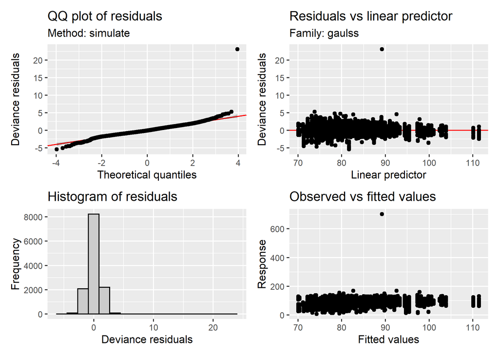

Below are the partial effects. Note that “s.1(wk)” is the partial effect of week on the standard deviation. This is centered and on the log-link scale, so you need to add the intercept (2.86) and take the exponent of those values to get the actual standard deviation (i.e., SD ranges 6.42 to 47.40 rather than -1 to 1). The other smooths are centered and on the response scale, so adding the intercept (82.68) will get you the predicted length.

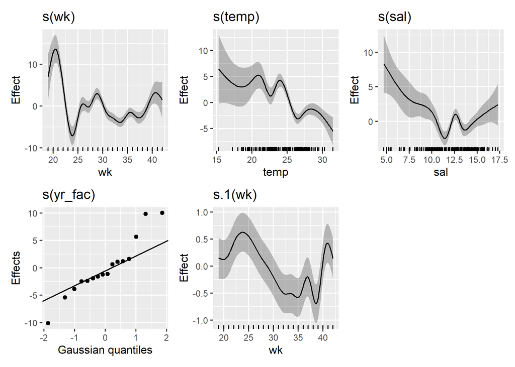

#### Growth rate

Now for something really neat: the *derivative* of the partial effect of week represents the **growth rate** in millimeters per week (change in length over change in time)!!

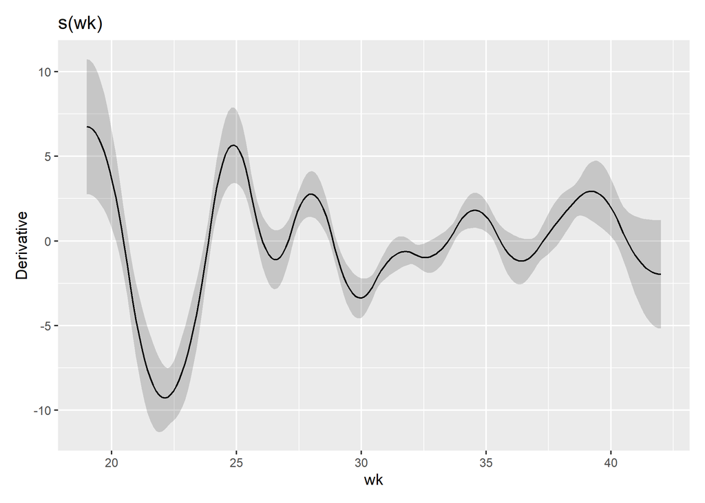

What I think may be happening here is this: rapid decreases in the derivative of length represent batches of YOY silverside recruiting into the gear; we get repeated influxes of smaller fish, making the “growth rate” of the sampled population become negative. As these fish grow, the “growth rate” becomes less and less negative until the next batch of recruits come in. I may be interpreting this wrong, but the swings from positive to negative in the plot above might represent batch spawning – would it make sense that these pulses occur in 2-5 week intervals?

### Atlantic needlefish

```r
ndl <- lengths[grepl('strong', scientific)]

ndl_mod <- gam(list(length ~
                      s(wk, k = 15, bs = 'cs') +
                      s(temp, bs = 'cs')+
                      s(sal, bs = 'cs') +
                      s(yr_fac, bs = 're'),
                    ~ s(wk, k = 15, bs = 'cs')),
               family = 'gaulss',
               data = ndl,
               method = 'REML',
               control = gam.control(nthreads = 16))

summary(ndl_mod)
```

```
##
## Family: gaulss
## Link function: identity logb
##
## Formula:
## length ~ s(wk, k = 15, bs = "cs") + s(temp, bs = "cs") + s(sal,
##     bs = "cs") + s(yr_fac, bs = "re")
## ~s(wk, k = 15, bs = "cs")
##
## Parametric coefficients:
##                Estimate Std. Error z value Pr(>|z|)
## (Intercept)   220.09581    4.72284    46.6   <2e-16 ***
## (Intercept).1   3.70258    0.02054   180.2   <2e-16 ***
## ---
## Signif. codes:  0 '***' 0.001 '**' 0.01 '*' 0.05 '.' 0.1 ' ' 1
##
## Approximate significance of smooth terms:
##                 edf Ref.df  Chi.sq p-value
## s(wk)     8.731e+00     14 6629.23  <2e-16 ***
## s(temp)   1.164e+00      9   10.28  0.0361 *
## s(sal)    2.977e-04      9    0.00  0.7947
## s(yr_fac) 1.220e+01     14  207.74  <2e-16 ***
## s.1(wk)   8.702e+00     14  394.66  <2e-16 ***
## ---
## Signif. codes:  0 '***' 0.001 '**' 0.01 '*' 0.05 '.' 0.1 ' ' 1
##
## Deviance explained = 90.1%
## -REML = 6232.1  Scale est. = 1         n = 1203
```

Wow – well this one fit a lot better (90% deviance explained). Salinity has been penalized out of the model, so I’m going to refit the model without it.

```r
ndl_mod <- gam(list(length ~
                      s(wk, k = 15, bs = 'cs') +
                      s(temp, k = 15, bs = 'cs')+
                      s(yr_fac, bs = 're'),
                    ~ s(wk, k = 15, bs = 'cs')),
               family = 'gaulss',
               data = ndl,
               method = 'REML',
               control = gam.control(nthreads = 16))

summary(ndl_mod)
```

```
##
## Family: gaulss
## Link function: identity logb
##
## Formula:
## length ~ s(wk, k = 15, bs = "cs") + s(temp, k = 15, bs = "cs") +
##     s(yr_fac, bs = "re")
## ~s(wk, k = 15, bs = "cs")
##
## Parametric coefficients:
##                Estimate Std. Error z value Pr(>|z|)
## (Intercept)   219.23765    4.46091   49.15   <2e-16 ***
## (Intercept).1   3.72045    0.01998  186.24   <2e-16 ***
## ---
## Signif. codes:  0 '***' 0.001 '**' 0.01 '*' 0.05 '.' 0.1 ' ' 1
##
## Approximate significance of smooth terms:
##              edf Ref.df  Chi.sq p-value
## s(wk)      5.628     14 5729.74  <2e-16 ***
## s(temp)    1.707     14   15.69  0.0238 *
## s(yr_fac) 11.981     14  186.84  <2e-16 ***
## s.1(wk)    9.115     14  391.34  <2e-16 ***
## ---
## Signif. codes:  0 '***' 0.001 '**' 0.01 '*' 0.05 '.' 0.1 ' ' 1
##
## Deviance explained = 89.8%
## -REML =   6580  Scale est. = 1         n = 1268
```

The model diagnostics look pretty good (except for one pesky value – I need to see if this is the same as the one from the Atl. silverside model).

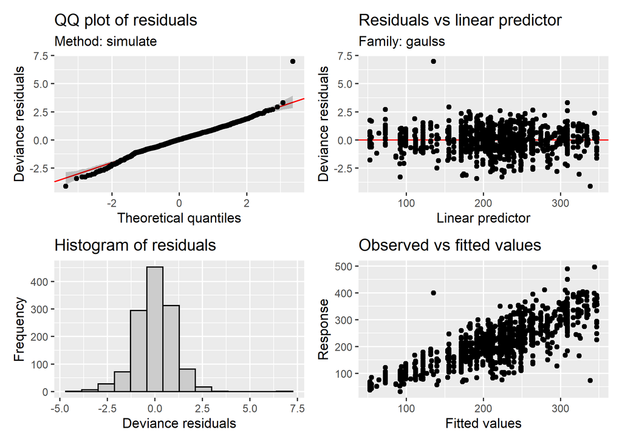

And the partial effects:

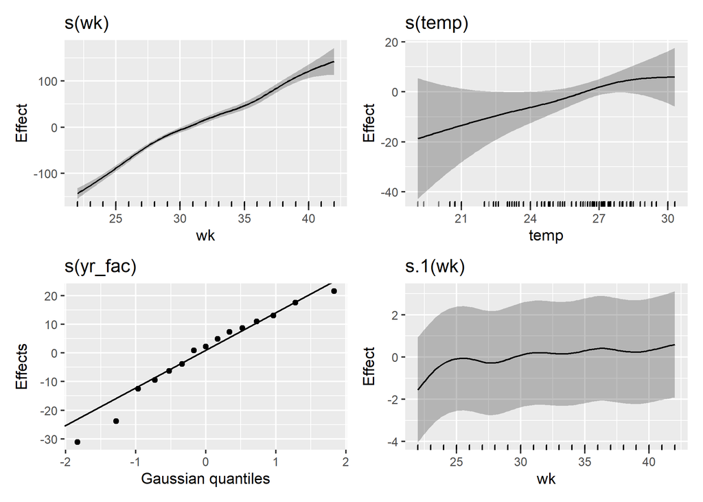

#### Growth rate

Needlefish seem to be growing pretty quickly here, on the order of >10 mm/wk. This growth rate is depressed between week 30 and 35 – I wonder if this is a mixture of cohorts or some other effect (too hot?).

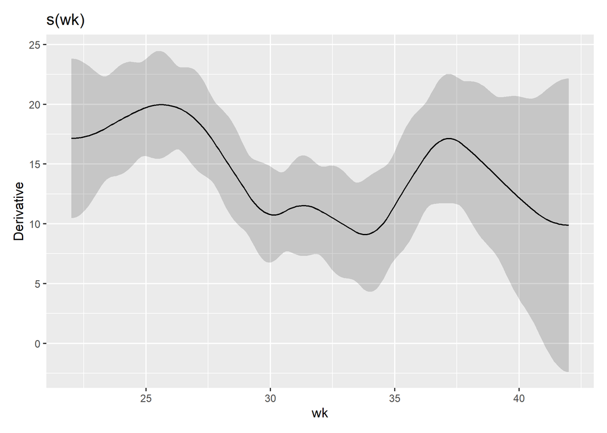

### Blue crab

```r
crb <- lengths[grepl('cal', scientific)]

crb_mod <- gam(list(length ~
                      s(wk, k = 15, bs = 'cs') +
                      s(temp, k = 15, bs = 'cs') +
                      s(sal, k = 15, bs = 'cs') +
                      s(yr_fac, bs = 're'),
                    ~ s(wk, k = 15, bs = 'cs')),
               family = 'gaulss',
               data = crb,
               method = 'REML',
               control = gam.control(nthreads = 16))

summary(crb_mod)
```

```
##
## Family: gaulss
## Link function: identity logb
##
## Formula:
## length ~ s(wk, k = 15, bs = "cs") + s(temp, k = 15, bs = "cs") +
##     s(sal, k = 15, bs = "cs") + s(yr_fac, bs = "re")
## ~s(wk, k = 15, bs = "cs")
##
## Parametric coefficients:
##               Estimate Std. Error z value Pr(>|z|)
## (Intercept)   49.60509    2.04155    24.3   <2e-16 ***
## (Intercept).1  3.34679    0.03262   102.6   <2e-16 ***
## ---
## Signif. codes:  0 '***' 0.001 '**' 0.01 '*' 0.05 '.' 0.1 ' ' 1
##
## Approximate significance of smooth terms:
##               edf Ref.df Chi.sq p-value
## s(wk)     4.33586     14 48.240 < 2e-16 ***
## s(temp)   2.79769     14  9.652 0.00966 **
## s(sal)    0.08961     14  0.110 0.27913
## s(yr_fac) 6.38973     15 16.443 0.00170 **
## s.1(wk)   1.79162     14 48.195 < 2e-16 ***
## ---
## Signif. codes:  0 '***' 0.001 '**' 0.01 '*' 0.05 '.' 0.1 ' ' 1
##
## Deviance explained = 32.1%
## -REML = 2329.8  Scale est. = 1         n = 483
```

Salinity looks to have been penalized out of the model again, so refitting without it:

```r
crb_mod <- gam(list(length ~
                      s(wk, k = 15, bs = 'cs') +
                      s(temp, k = 15, bs = 'cs') +
                      s(yr_fac, bs = 're'),
                    ~ s(wk, k = 15, bs = 'cs')),
               family = 'gaulss',
               data = crb,
               method = 'REML',
               control = gam.control(nthreads = 16))

summary(crb_mod)
```

```
##
## Family: gaulss
## Link function: identity logb
##
## Formula:
## length ~ s(wk, k = 15, bs = "cs") + s(temp, k = 15, bs = "cs") +
##     s(yr_fac, bs = "re")
## ~s(wk, k = 15, bs = "cs")
##
## Parametric coefficients:
##               Estimate Std. Error z value Pr(>|z|)
## (Intercept)   49.64957    2.05370   24.18   <2e-16 ***
## (Intercept).1  3.34638    0.03244  103.14   <2e-16 ***
## ---
## Signif. codes:  0 '***' 0.001 '**' 0.01 '*' 0.05 '.' 0.1 ' ' 1
##
## Approximate significance of smooth terms:
##             edf Ref.df Chi.sq p-value
## s(wk)     4.311     14 47.459 < 2e-16 ***
## s(temp)   2.714     14  9.162 0.01171 *
## s(yr_fac) 6.576     15 17.323 0.00135 **
## s.1(wk)   1.805     14 47.953 < 2e-16 ***
## ---
## Signif. codes:  0 '***' 0.001 '**' 0.01 '*' 0.05 '.' 0.1 ' ' 1
##
## Deviance explained = 31.8%
## -REML = 2353.4  Scale est. = 1         n = 488
```

These model diagnostics aren’t great and suggest that I need to use a different error family. I’ll do that later, but for now I’ll just plot ahead.

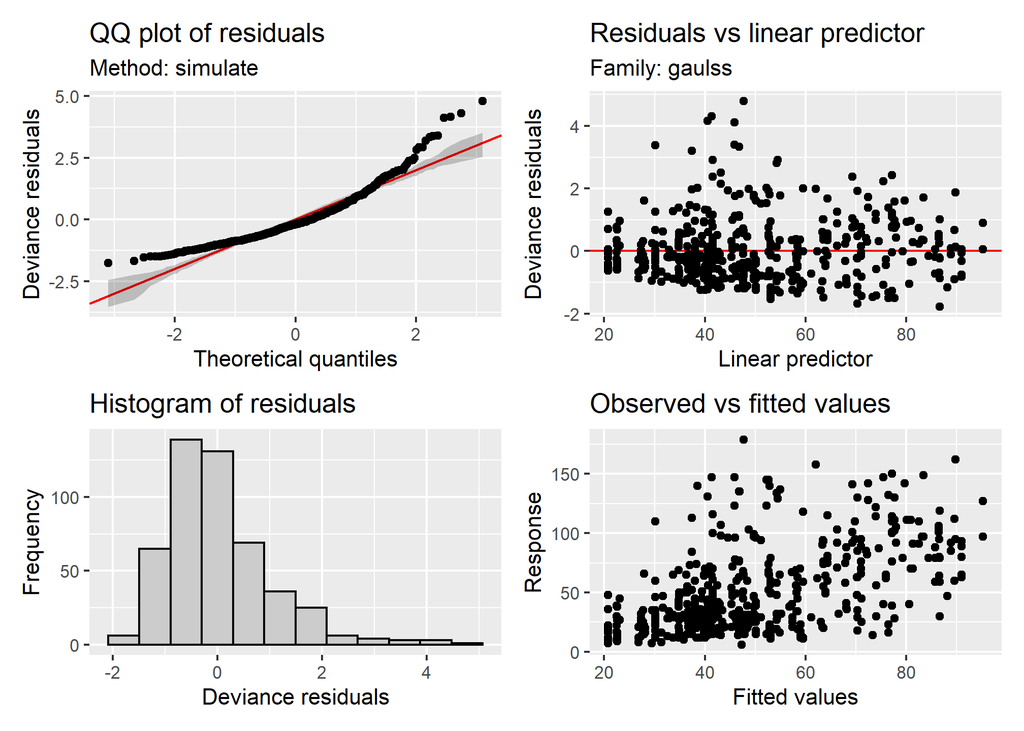

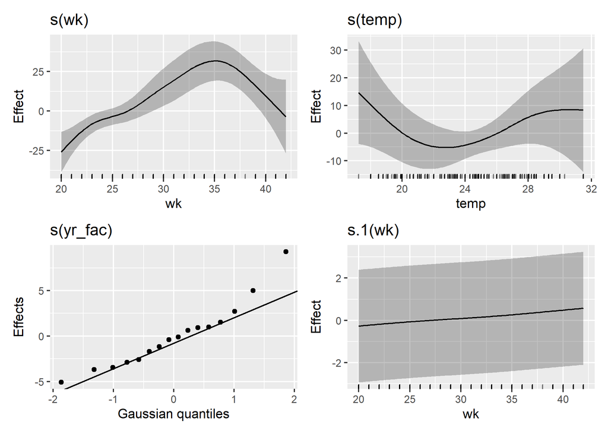

Hmm. Looks like baby crabs start coming in around week 35, and that this doesn’t affect the variance too much. I imagine that if we move forward with blue crab, a much simpler model would suffice.

#### Growth rate

Crabby growth rate seems to be ~5 mm/wk until YOY recruit in around week 35.

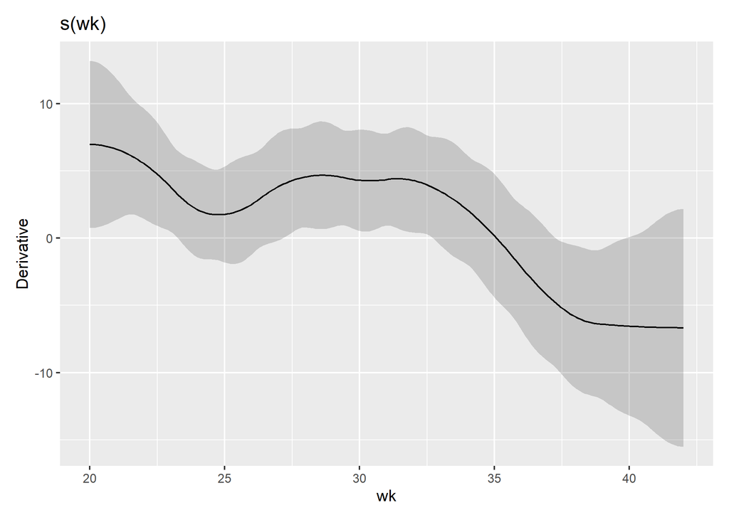

### Spot

```r
spt <- lengths[grepl('xan', scientific)]

spt_mod <- gam(list(length ~
                      s(wk, k = 15, bs = 'cs') +
                      s(temp, k = 15, bs = 'cs') +
                      s(sal, k = 15, bs = 'cs') +
                      s(yr_fac, bs = 're'),
                    ~ s(wk, k = 15, bs = 'cs')),
               family = 'gaulss',
               data = spt,
               method = 'REML',
               control = gam.control(nthreads = 16))

summary(spt_mod)
```

```
##
## Family: gaulss
## Link function: identity logb
##
## Formula:
## length ~ s(wk, k = 15, bs = "cs") + s(temp, k = 15, bs = "cs") +
##     s(sal, k = 15, bs = "cs") + s(yr_fac, bs = "re")
## ~s(wk, k = 15, bs = "cs")
##
## Parametric coefficients:
##               Estimate Std. Error z value Pr(>|z|)
## (Intercept)   73.43779    4.54879   16.14   <2e-16 ***
## (Intercept).1  2.90438    0.01463  198.57   <2e-16 ***
## ---
## Signif. codes:  0 '***' 0.001 '**' 0.01 '*' 0.05 '.' 0.1 ' ' 1
##
## Approximate significance of smooth terms:
##              edf Ref.df Chi.sq p-value
## s(wk)      7.837     14 1560.8  <2e-16 ***
## s(temp)   11.175     14  634.8  <2e-16 ***
## s(sal)     8.036     14  935.7  <2e-16 ***
## s(yr_fac) 13.908     15  811.0  <2e-16 ***
## s.1(wk)   10.481     14  495.7  <2e-16 ***
## ---
## Signif. codes:  0 '***' 0.001 '**' 0.01 '*' 0.05 '.' 0.1 ' ' 1
##
## Deviance explained = 71.8%
## -REML =  10373  Scale est. = 1         n = 2366
```

Model diagnostics aren’t perfect, but good for now.

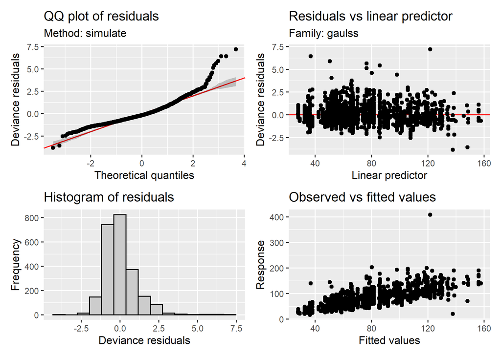

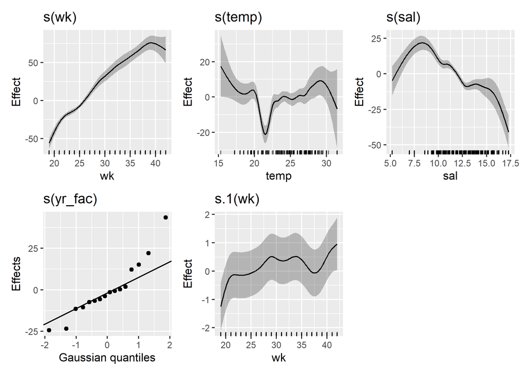

#### Growth rate

Starting to see a pattern here: growth rate is most consistent in weeks 30-35. Perhaps this isn’t depression of the rate, but the actual growth rate.

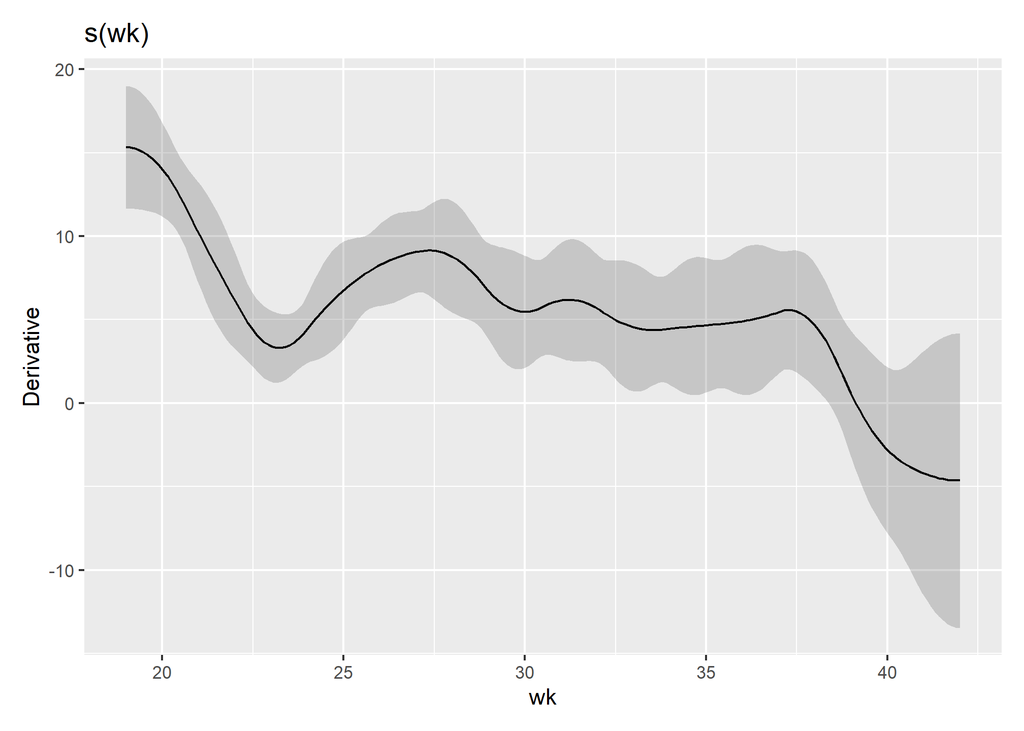

### Inland silverside

```r
inl <- lengths[grepl('beryl', scientific)]

inl_mod <- gam(list(length ~
                      s(wk, k = 15, bs = 'cs') +
                      s(temp, k = 15, bs = 'cs') +
                      s(sal, k = 15, bs = 'cs') +
                      s(yr_fac, bs = 're'),
                    ~ s(wk, k = 15, bs = 'cs')),
               family = 'gaulss',
               data = inl,
               method = 'REML',
               control = gam.control(nthreads = 16))

summary(inl_mod)
```

```
##
## Family: gaulss
## Link function: identity logb
##
## Formula:
## length ~ s(wk, k = 15, bs = "cs") + s(temp, k = 15, bs = "cs") +
##     s(sal, k = 15, bs = "cs") + s(yr_fac, bs = "re")
## ~s(wk, k = 15, bs = "cs")
##
## Parametric coefficients:
##               Estimate Std. Error z value Pr(>|z|)
## (Intercept)   72.05723    0.82763   87.06   <2e-16 ***
## (Intercept).1  2.32377    0.02192  106.02   <2e-16 ***
## ---
## Signif. codes:  0 '***' 0.001 '**' 0.01 '*' 0.05 '.' 0.1 ' ' 1
##
## Approximate significance of smooth terms:
##                 edf Ref.df  Chi.sq p-value
## s(wk)     8.170e+00     14  415.58 < 2e-16 ***
## s(temp)   7.398e+00     14  282.81 < 2e-16 ***
## s(sal)    1.888e-04     14    0.00 0.23219
## s(yr_fac) 6.464e+00     11   21.26 0.00025 ***
## s.1(wk)   1.278e+01     14 1337.60 < 2e-16 ***
## ---
## Signif. codes:  0 '***' 0.001 '**' 0.01 '*' 0.05 '.' 0.1 ' ' 1
##
## Deviance explained = 45.9%
## -REML = 4060.2  Scale est. = 1         n = 1058
```

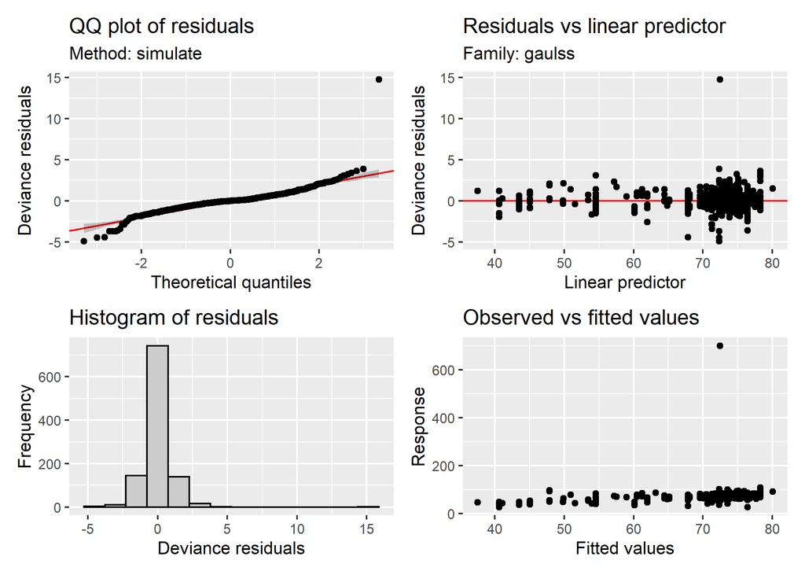

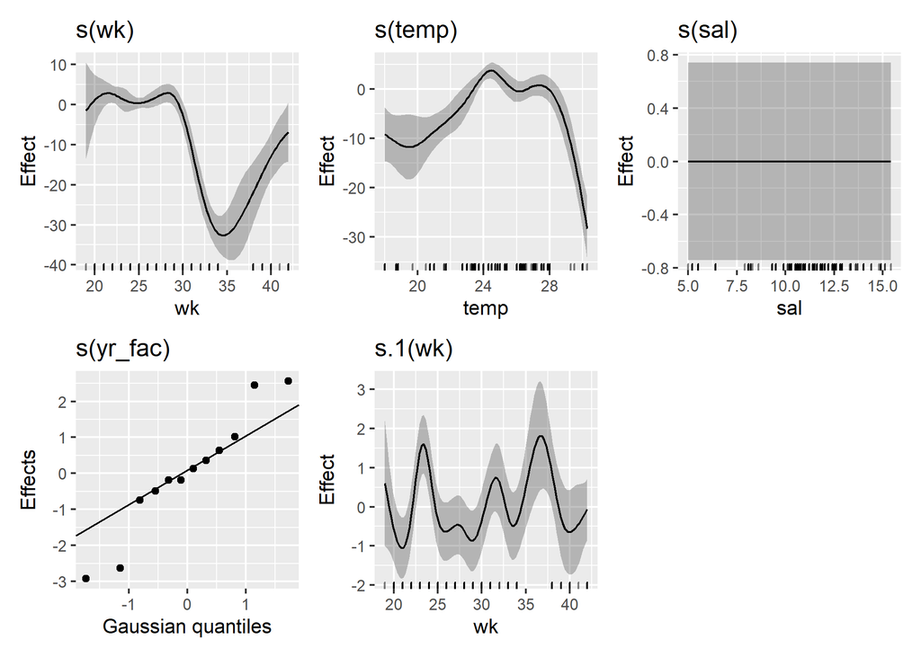

#### Growth rate

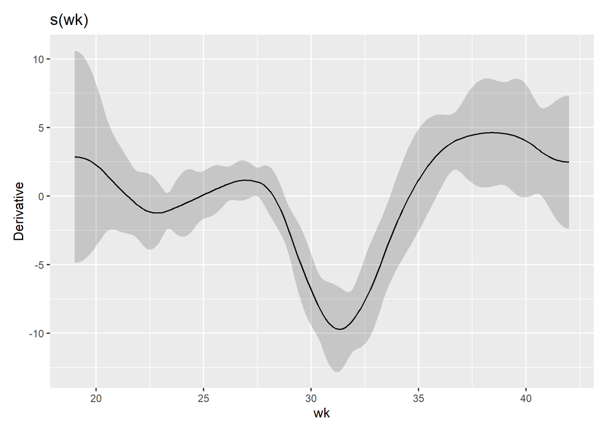

### Striped bass

```r
sb <- lengths[grepl('morone sax', scientific)]

sb_mod <- gam(list(length ~
                      s(wk, k = 15, bs = 'cs') +
                      s(temp, k = 15, bs = 'cs') +
                      s(sal, k = 15, bs = 'cs') +
                      s(yr_fac, bs = 're'),
                    ~ s(wk, k = 15, bs = 'cs')),
               family = 'gaulss',
               data = sb,
               method = 'REML',
               control = gam.control(nthreads = 16))

summary(sb_mod)
```

```
##
## Family: gaulss
## Link function: identity logb
##
## Formula:
## length ~ s(wk, k = 15, bs = "cs") + s(temp, k = 15, bs = "cs") +
##     s(sal, k = 15, bs = "cs") + s(yr_fac, bs = "re")
## ~s(wk, k = 15, bs = "cs")
##
## Parametric coefficients:
##               Estimate Std. Error z value Pr(>|z|)
## (Intercept)   84.45487    7.26730   11.62   <2e-16 ***
## (Intercept).1  2.42158    0.02447   98.97   <2e-16 ***
## ---
## Signif. codes:  0 '***' 0.001 '**' 0.01 '*' 0.05 '.' 0.1 ' ' 1
##
## Approximate significance of smooth terms:
##               edf Ref.df Chi.sq p-value
## s(wk)      3.8547     14 3911.6  <2e-16 ***
## s(temp)    0.7476     14   15.2  0.0454 *
## s(sal)     5.3203     14  336.0  0.1044
## s(yr_fac) 12.1654     15  372.9  <2e-16 ***
## s.1(wk)   13.2296     14 1347.1  <2e-16 ***
## ---
## Signif. codes:  0 '***' 0.001 '**' 0.01 '*' 0.05 '.' 0.1 ' ' 1
##
## Deviance explained = 90.8%
## -REML = 3378.6  Scale est. = 1         n = 852
```

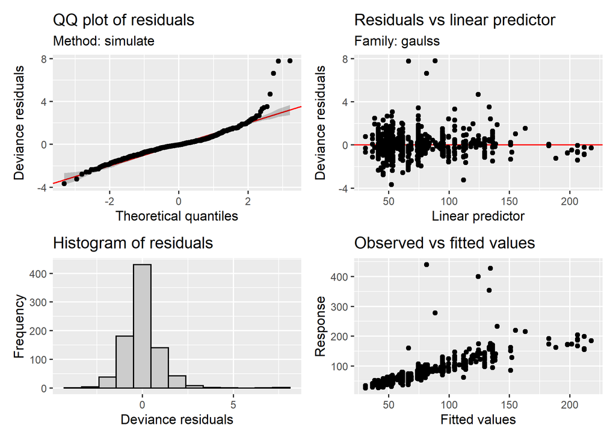

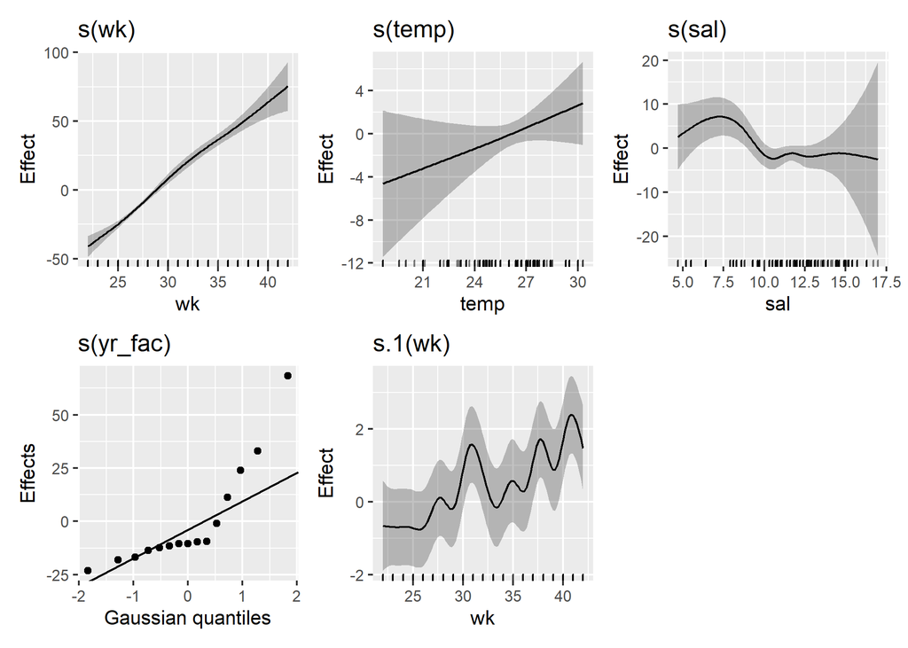

#### Growth rate

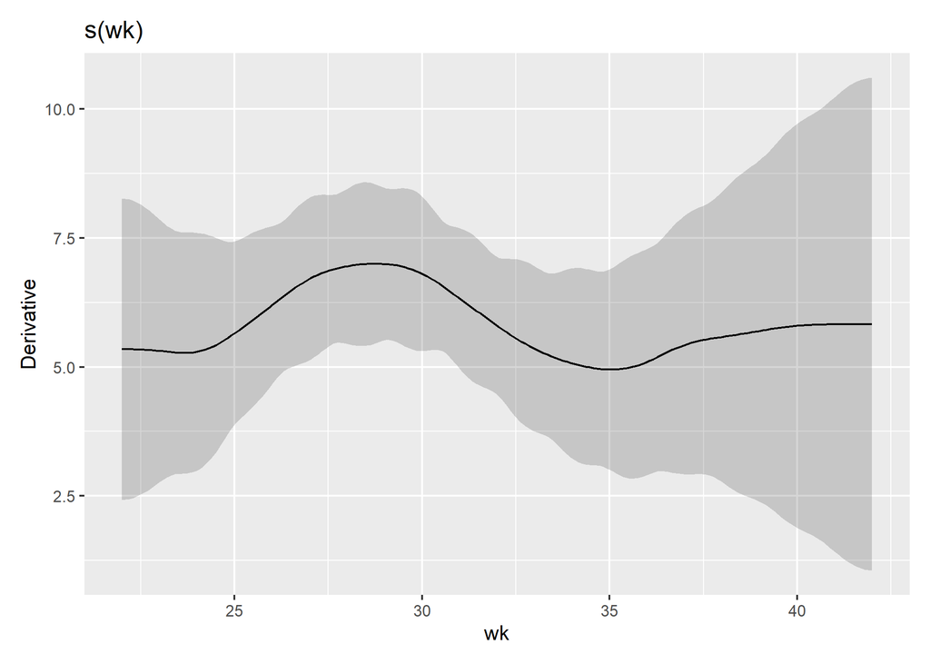

### Bluefish

```r
bfish <- lengths[grepl('salt', scientific)]

bfish_mod <- gam(list(length ~
                      s(wk, k = 15, bs = 'cs') +
                      s(temp, k = 15, bs = 'cs') +
                      s(sal, k = 15, bs = 'cs') +
                      s(yr_fac, bs = 're'),
                    ~ s(wk, k = 15, bs = 'cs')),
               family = 'gaulss',
               data = bfish,
               method = 'REML',
               control = gam.control(nthreads = 16))

summary(bfish_mod)
```

```
##
## Family: gaulss
## Link function: identity logb
##
## Formula:
## length ~ s(wk, k = 15, bs = "cs") + s(temp, k = 15, bs = "cs") +
##     s(sal, k = 15, bs = "cs") + s(yr_fac, bs = "re")
## ~s(wk, k = 15, bs = "cs")
##
## Parametric coefficients:
##               Estimate Std. Error z value Pr(>|z|)
## (Intercept)   99.30556    2.37929   41.74   <2e-16 ***
## (Intercept).1  2.63020    0.04505   58.38   <2e-16 ***
## ---
## Signif. codes:  0 '***' 0.001 '**' 0.01 '*' 0.05 '.' 0.1 ' ' 1
##
## Approximate significance of smooth terms:
##                 edf Ref.df    Chi.sq p-value
## s(wk)      9.998789     14 1.833e+05  <2e-16 ***
## s(temp)    1.047846     14 2.394e+04  0.0798 .
## s(sal)     0.001403     14 2.000e-03  0.2665
## s(yr_fac) 13.469236     16 2.872e+02  <2e-16 ***
## s.1(wk)   12.881329     14 7.940e+02  <2e-16 ***
## ---
## Signif. codes:  0 '***' 0.001 '**' 0.01 '*' 0.05 '.' 0.1 ' ' 1
##
## Deviance explained =  100%
## -REML = 3077.5  Scale est. = 1         n = 690
```

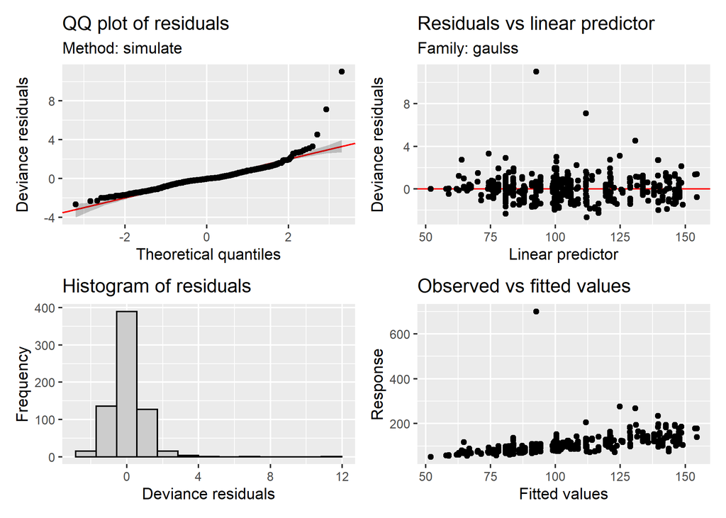

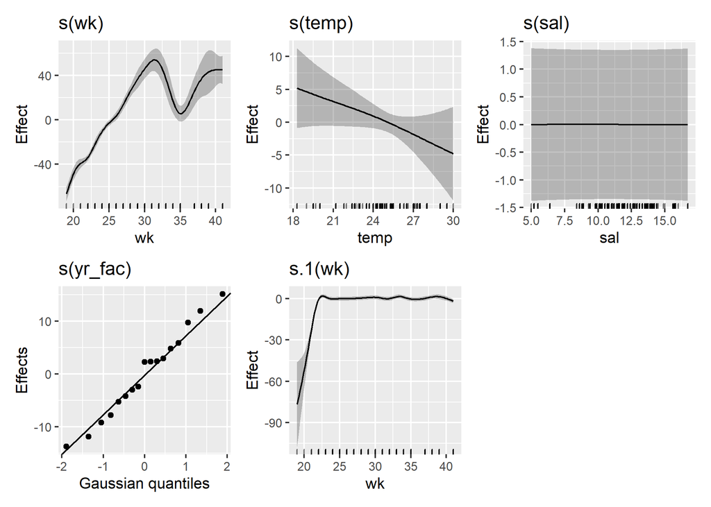

#### Growth rate

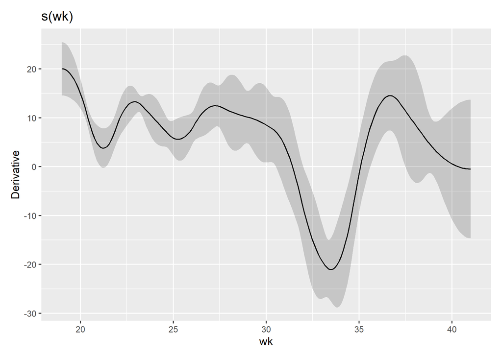

### Bay anchovy

```r
banch <- lengths[grepl('mitch', scientific)]

banch_mod <- gam(list(length ~
                      s(wk, k = 15, bs = 'cs') +
                      s(temp, k = 15, bs = 'cs') +
                      s(sal, k = 15, bs = 'cs') +
                      s(yr_fac, bs = 're'),
                    ~ s(wk, k = 15, bs = 'cs')),
               family = 'gaulss',
               data = banch,
               method = 'REML',
               control = gam.control(nthreads = 16))

summary(banch_mod)
```

```
##
## Family: gaulss
## Link function: identity logb
##
## Formula:
## length ~ s(wk, k = 15, bs = "cs") + s(temp, k = 15, bs = "cs") +
##     s(sal, k = 15, bs = "cs") + s(yr_fac, bs = "re")
## ~s(wk, k = 15, bs = "cs")
##
## Parametric coefficients:
##               Estimate Std. Error z value Pr(>|z|)
## (Intercept)   51.49335    3.99623   12.88   <2e-16 ***
## (Intercept).1  1.59768    0.02075   77.01   <2e-16 ***
## ---
## Signif. codes:  0 '***' 0.001 '**' 0.01 '*' 0.05 '.' 0.1 ' ' 1
##
## Approximate significance of smooth terms:
##              edf Ref.df Chi.sq p-value
## s(wk)     13.197     14  952.2  <2e-16 ***
## s(temp)   12.762     14 2177.2  <2e-16 ***
## s(sal)    12.014     14 1352.2  <2e-16 ***
## s(yr_fac) 12.056     14  256.0  <2e-16 ***
## s.1(wk)    7.965     14  138.3  <2e-16 ***
## ---
## Signif. codes:  0 '***' 0.001 '**' 0.01 '*' 0.05 '.' 0.1 ' ' 1
##
## Deviance explained = 90.8%
## -REML = 3825.9  Scale est. = 1         n = 1195
```

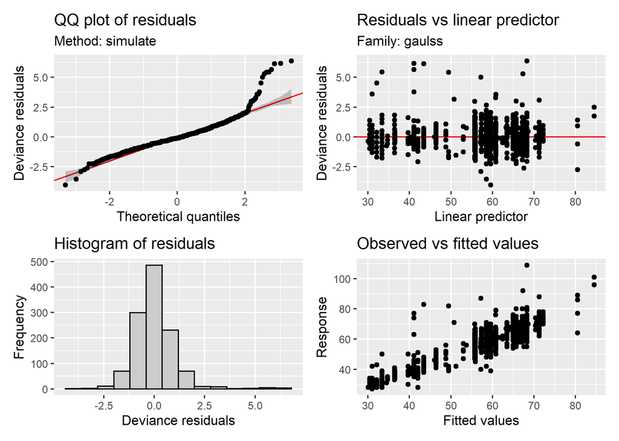

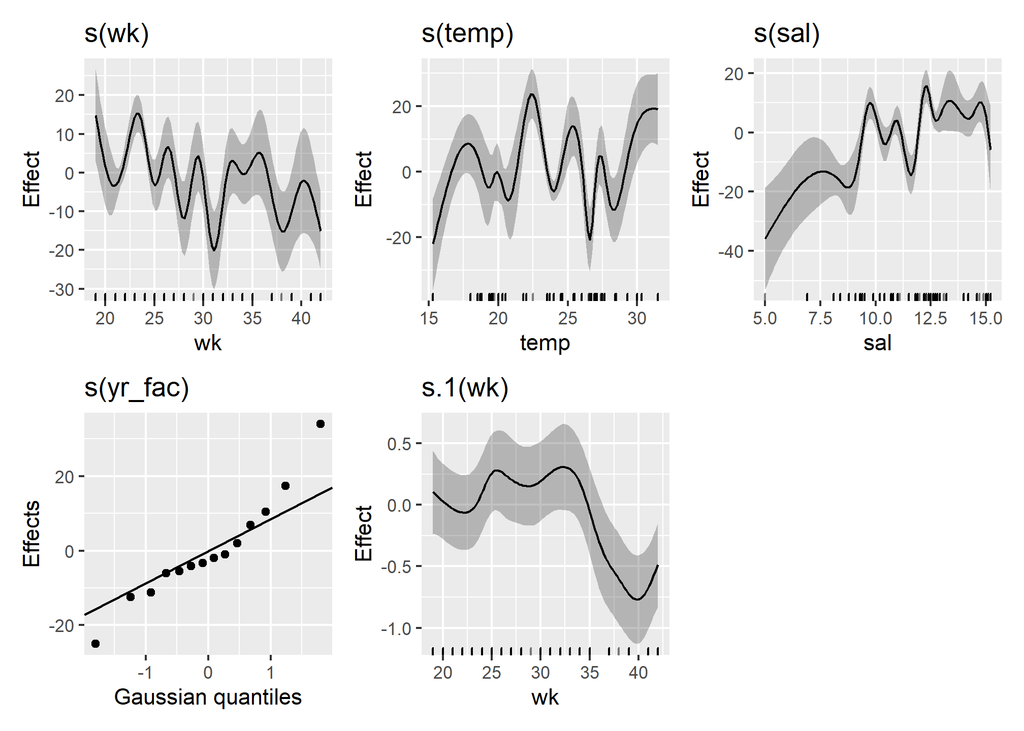

#### Growth rate

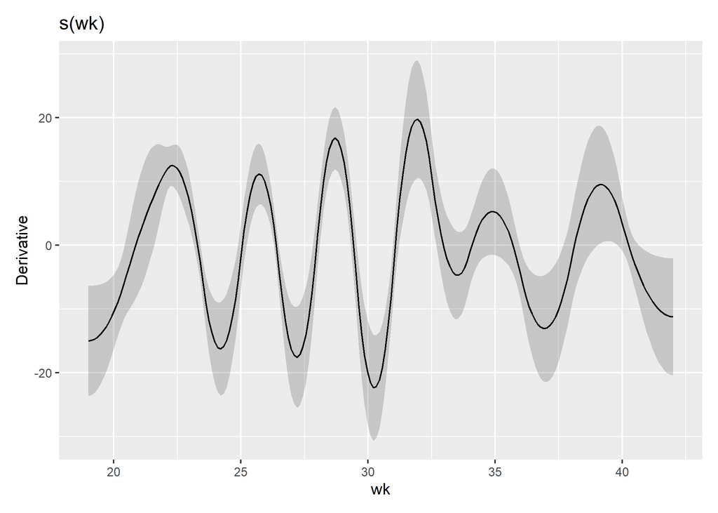

### Menhaden

```r
menh <- lengths[grepl('brev', scientific)]

menh_mod <- gam(list(length ~
                      s(wk, k = 15, bs = 'cs') +
                      s(temp, k = 15, bs = 'cs') +
                      s(sal, k = 15, bs = 'cs') +
                      s(yr_fac, bs = 're'),
                    ~ s(wk, k = 15, bs = 'cs')),
               family = 'gaulss',
               data = menh,
               method = 'REML',
               control = gam.control(nthreads = 16))

summary(menh_mod)
```

```
##
## Family: gaulss
## Link function: identity logb
##
## Formula:
## length ~ s(wk, k = 15, bs = "cs") + s(temp, k = 15, bs = "cs") +
##     s(sal, k = 15, bs = "cs") + s(yr_fac, bs = "re")
## ~s(wk, k = 15, bs = "cs")
##
## Parametric coefficients:
##               Estimate Std. Error z value Pr(>|z|)
## (Intercept)   92.81561    2.95952   31.36   <2e-16 ***
## (Intercept).1  2.06109    0.01817  113.41   <2e-16 ***
## ---
## Signif. codes:  0 '***' 0.001 '**' 0.01 '*' 0.05 '.' 0.1 ' ' 1
##
## Approximate significance of smooth terms:
##              edf Ref.df Chi.sq p-value
## s(wk)      9.106     14 5218.0  <2e-16 ***
## s(temp)   12.568     14 2357.5  <2e-16 ***
## s(sal)     7.551     14 1425.4  <2e-16 ***
## s(yr_fac) 11.891     14  389.9  <2e-16 ***
## s.1(wk)   12.690     14  759.7  <2e-16 ***
## ---
## Signif. codes:  0 '***' 0.001 '**' 0.01 '*' 0.05 '.' 0.1 ' ' 1
##
## Deviance explained = 97.1%
## -REML = 5548.7  Scale est. = 1         n = 1544
```

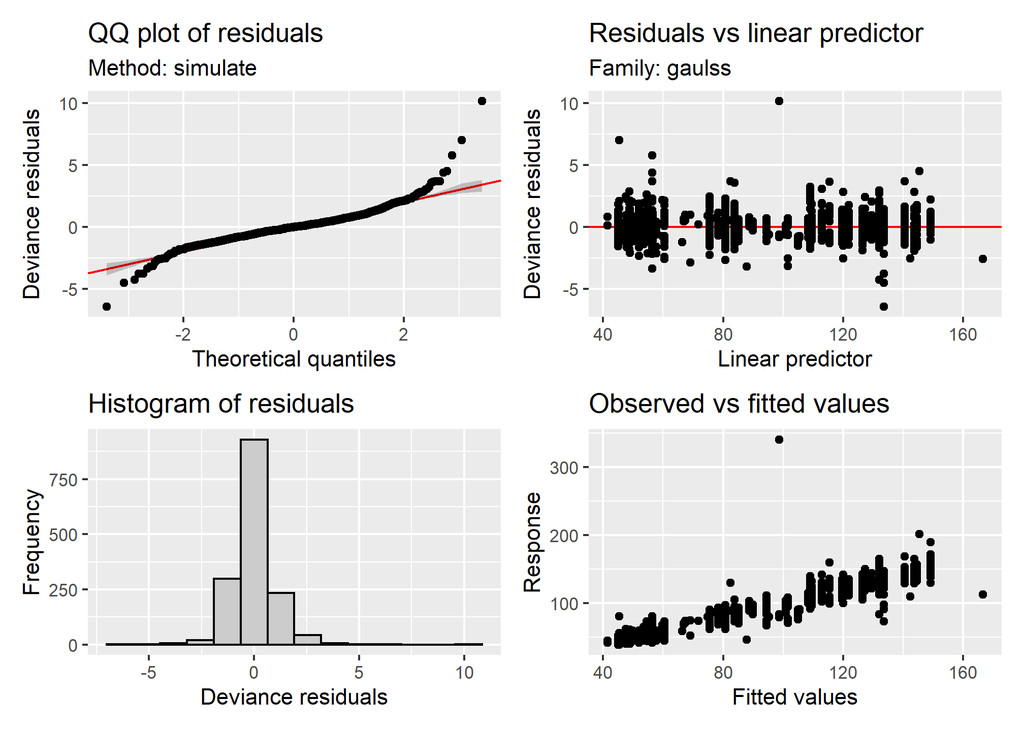

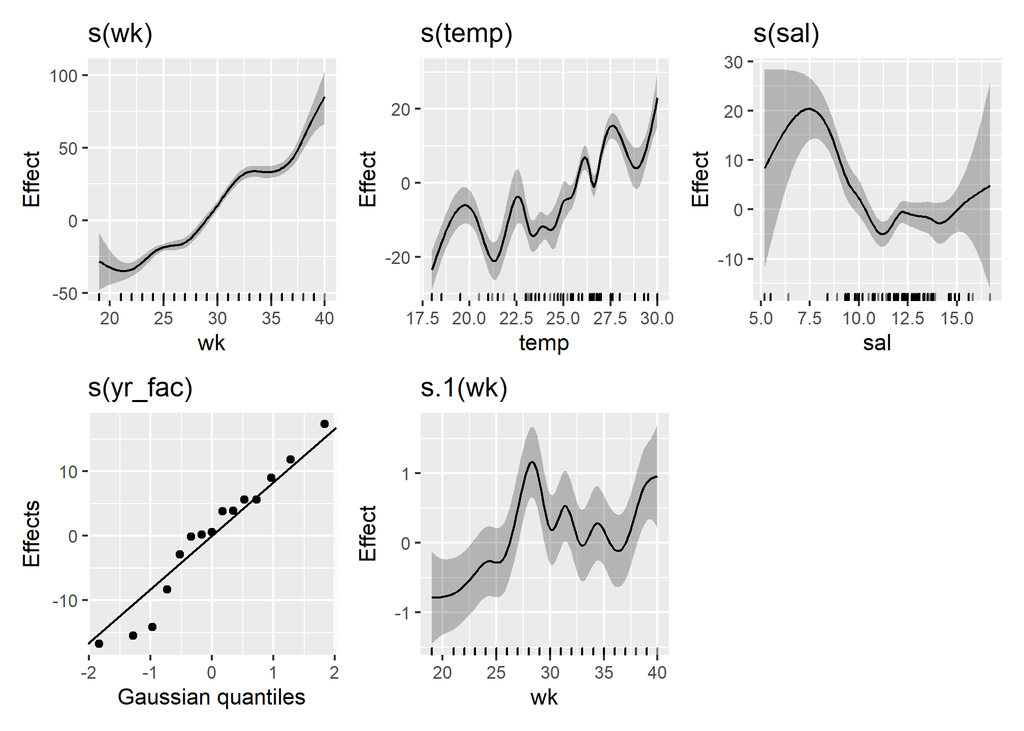

#### Growth rate

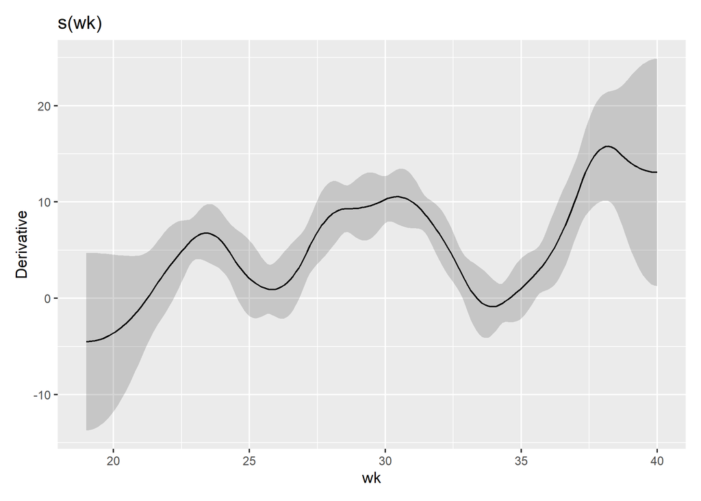

### Gizzard shad

```r
gizz <- lengths[grepl('cepe', scientific)]

gizz_mod <- gam(list(length ~
                      s(wk, k = 15, bs = 'cs') +
                      s(temp, k = 15, bs = 'cs') +
                      s(sal, k = 15, bs = 'cs') +
                      s(yr_fac, bs = 're'),
                    ~ s(wk, k = 15, bs = 'cs')),
               family = 'gaulss',
               data = gizz,
               method = 'REML',
               control = gam.control(nthreads = 16))

summary(gizz_mod)
```

```
##
## Family: gaulss
## Link function: identity logb
##
## Formula:
## length ~ s(wk, k = 15, bs = "cs") + s(temp, k = 15, bs = "cs") +
##     s(sal, k = 15, bs = "cs") + s(yr_fac, bs = "re")
## ~s(wk, k = 15, bs = "cs")
##
## Parametric coefficients:
##                Estimate Std. Error z value Pr(>|z|)
## (Intercept)   384.99849   20.07500   19.18   <2e-16 ***
## (Intercept).1   3.30829    0.05759   57.44   <2e-16 ***
## ---
## Signif. codes:  0 '***' 0.001 '**' 0.01 '*' 0.05 '.' 0.1 ' ' 1
##
## Approximate significance of smooth terms:
##                 edf Ref.df   Chi.sq p-value
## s(wk)     6.247e-05     14    0.000   0.368
## s(temp)   1.815e-03     14    0.001   0.408
## s(sal)    5.615e+00     14 8428.431  <2e-16 ***
## s(yr_fac) 7.310e+00      8  702.072  <2e-16 ***
## s.1(wk)   4.036e+00     14   78.726  <2e-16 ***
## ---
## Signif. codes:  0 '***' 0.001 '**' 0.01 '*' 0.05 '.' 0.1 ' ' 1
##
## Deviance explained = 91.8%
## -REML = 795.83  Scale est. = 1         n = 159
```

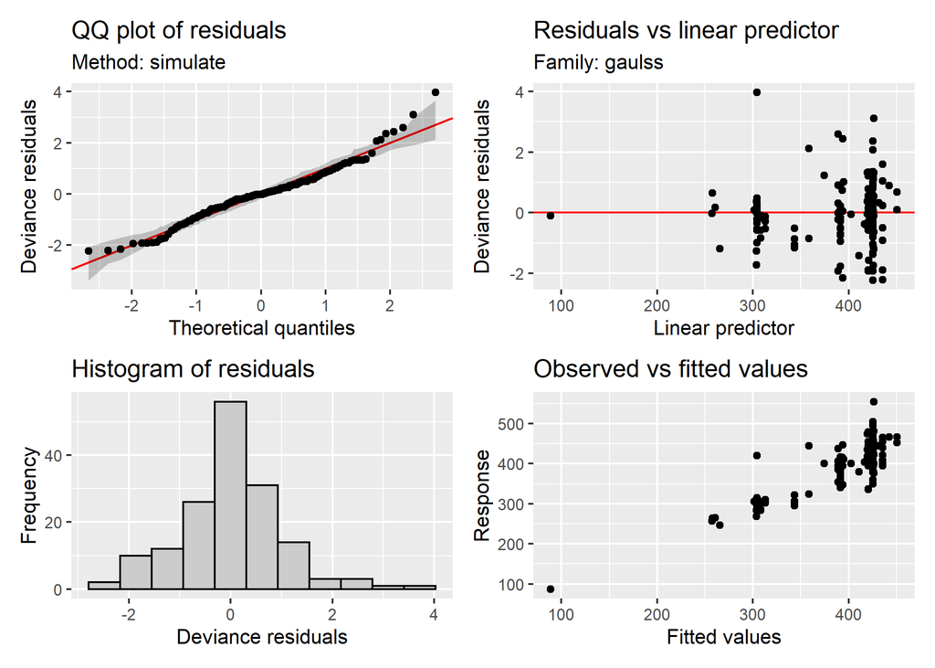

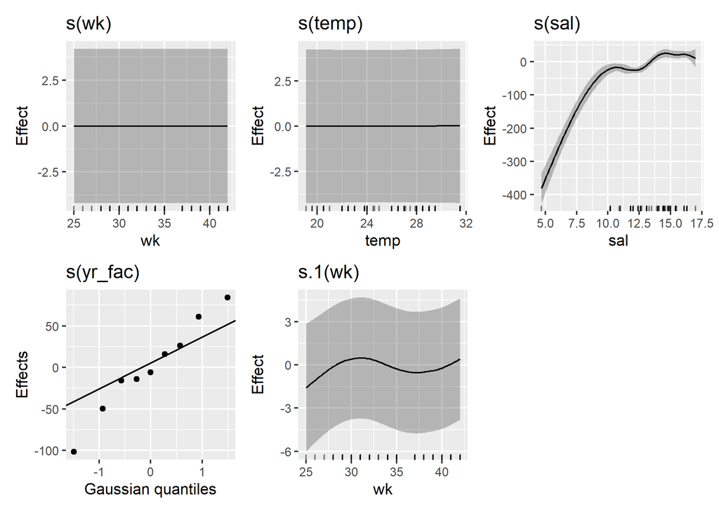

#### Growth rate

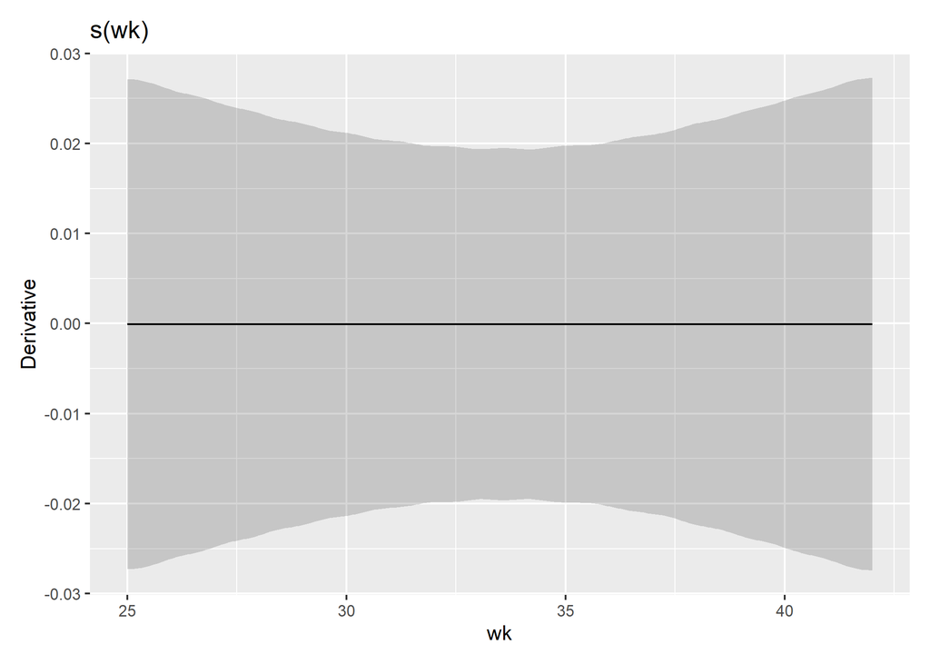